## United Nations General Assembly Voting Data

This package provides the voting history of countries in the [United Nations General Assembly](http://www.un.org/en/ga/), along with information such as date, description, and topics for each vote.

These come from the dataset [found here](https://dataverse.harvard.edu/dataset.xhtml?persistentId=hdl:1902.1/12379):

> Erik Voeten “Data and Analyses of Voting in the UN General Assembly” Routledge Handbook of International Organization, edited by Bob Reinalda (published May 27, 2013)

This raw data, and the processing script, can be found in the data-raw folder.

### Installation

Install the package with:

```r
install.packages("unvotes")
```

You can also install the development version of the package using devtools:

```r
devtools::install_github("dgrtwo/unvotes")
```

### Datasets

The package contains three datasets. First is the history of each country’s vote. These are represented in the `un_votes` dataset, with one row for each country/vote pair:

```r
library(dplyr)
library(unvotes)

un_votes
```

```
#> # A tibble: 869,937 × 4
#>     rcid country            country_code vote
#>    <dbl> <chr>              <chr>        <fct>
#>  1     3 United States      US           yes
#>  2     3 Canada             CA           no
#>  3     3 Cuba               CU           yes
#>  4     3 Haiti              HT           yes
#>  5     3 Dominican Republic DO           yes
#>  6     3 Mexico             MX           yes
#>  7     3 Guatemala          GT           yes
#>  8     3 Honduras           HN           yes
#>  9     3 El Salvador        SV           yes
#> 10     3 Nicaragua          NI           yes
#> # ℹ 869,927 more rows
```

The package also contains a dataset of information about each roll call vote, including the date, description, and relevant resolution that was voted on:

```r
un_roll_calls
```

```
#> # A tibble: 6,202 × 9
#>     rcid session importantvote date       unres   amend  para short        descr
#>    <int>   <dbl>         <int> <date>     <chr>   <int> <int> <chr>        <chr>
#>  1     3       1             0 1946-01-01 R/1/66      1     0 AMENDMENTS,… "TO …
#>  2     4       1             0 1946-01-02 R/1/79      0     0 SECURITY CO… "TO …
#>  3     5       1             0 1946-01-04 R/1/98      0     0 VOTING PROC… "TO …
#>  4     6       1             0 1946-01-04 R/1/107     0     0 DECLARATION… "TO …
#>  5     7       1             0 1946-01-02 R/1/295     1     0 GENERAL ASS… "TO …
#>  6     8       1             0 1946-01-05 R/1/297     1     0 ECOSOC POWE… "TO …
#>  7     9       1             0 1946-02-05 R/1/329     0     0 POST-WAR RE… "TO …
#>  8    10       1             0 1946-02-05 R/1/361     1     1 U.N. MEMBER… "TO …
#>  9    11       1             0 1946-02-05 R/1/376     0     0 TRUSTEESHIP… "TO …
#> 10    12       1             0 1946-02-06 R/1/394     1     1 COUNCIL MEM… "TO …
#> # ℹ 6,192 more rows
```

Finally, the `un_roll_call_issues` dataset shows relationships betwen each vote and 6 issues:

```r
un_roll_call_issues
```

```
#> # A tibble: 5,745 × 3
#>     rcid short_name issue
#>    <int> <chr>      <fct>
#>  1    77 me         Palestinian conflict
#>  2  9001 me         Palestinian conflict
#>  3  9002 me         Palestinian conflict
#>  4  9003 me         Palestinian conflict
#>  5  9004 me         Palestinian conflict
#>  6  9005 me         Palestinian conflict
#>  7  9006 me         Palestinian conflict
#>  8   128 me         Palestinian conflict
#>  9   129 me         Palestinian conflict
#> 10   130 me         Palestinian conflict
#> # ℹ 5,735 more rows
```

```r
count(un_roll_call_issues, issue, sort = TRUE)
```

```
#> # A tibble: 6 × 2
#>   issue                                    n
#>   <fct>                                <int>
#> 1 Arms control and disarmament          1092
#> 2 Palestinian conflict                  1061
#> 3 Human rights                          1015
#> 4 Colonialism                            957
#> 5 Nuclear weapons and nuclear material   855
#> 6 Economic development                   765
```

(Use `help()` to get information and documentation about each dataset).

### Example analysis

Many useful analyses will first involve joining the vote and roll call datasets by the shared `rcid` (roll call ID) column:

```r
library(dplyr)

joined <- un_votes %>%
  inner_join(un_roll_calls, by = "rcid")

joined
```

```
#> # A tibble: 869,937 × 12
#>     rcid country country_code vote  session importantvote date       unres amend
#>    <dbl> <chr>   <chr>        <fct>   <dbl>         <int> <date>     <chr> <int>
#>  1     3 United… US           yes         1             0 1946-01-01 R/1/…     1
#>  2     3 Canada  CA           no          1             0 1946-01-01 R/1/…     1
#>  3     3 Cuba    CU           yes         1             0 1946-01-01 R/1/…     1
#>  4     3 Haiti   HT           yes         1             0 1946-01-01 R/1/…     1
#>  5     3 Domini… DO           yes         1             0 1946-01-01 R/1/…     1
#>  6     3 Mexico  MX           yes         1             0 1946-01-01 R/1/…     1
#>  7     3 Guatem… GT           yes         1             0 1946-01-01 R/1/…     1
#>  8     3 Hondur… HN           yes         1             0 1946-01-01 R/1/…     1
#>  9     3 El Sal… SV           yes         1             0 1946-01-01 R/1/…     1
#> 10     3 Nicara… NI           yes         1             0 1946-01-01 R/1/…     1
#> # ℹ 869,927 more rows
#> # ℹ 3 more variables: para <int>, short <chr>, descr <chr>
```

One could then count how often each country votes “yes” on a resolution in each year:

```r
library(lubridate)

by_country_year <- joined %>%
  group_by(year = year(date), country) %>%
  summarize(votes = n(),
            percent_yes = mean(vote == "yes"))

by_country_year
```

```
#> # A tibble: 10,461 × 4
#> # Groups:   year [73]
#>     year country     votes percent_yes
#>    <dbl> <chr>       <int>       <dbl>
#>  1  1946 Afghanistan    17       0.412
#>  2  1946 Argentina      43       0.698
#>  3  1946 Australia      43       0.558
#>  4  1946 Belarus        43       0.442
#>  5  1946 Belgium        43       0.605
#>  6  1946 Bolivia        43       0.698
#>  7  1946 Brazil         43       0.605
#>  8  1946 Canada         42       0.643
#>  9  1946 Chile          43       0.605
#> 10  1946 Colombia       42       0.310
#> # ℹ 10,451 more rows
```

After which this can be visualized for one or more countries:

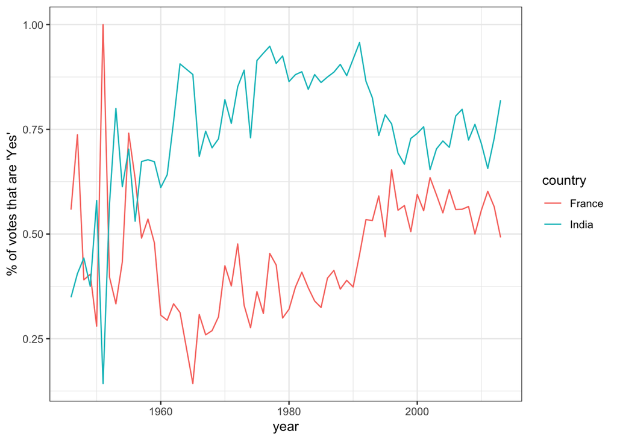

```r
library(ggplot2)
theme_set(theme_bw())

countries <- c("United States of America", "India", "France")

# there were fewer votes in 2013
by_country_year %>%
  filter(country %in% countries, year <= 2013) %>%
  ggplot(aes(year, percent_yes, color = country)) +
  geom_line() +
  ylab("% of votes that are 'Yes'")
```

Similarly, we could look at how the voting record of the United States has changed on each of the issues by joining with the `un_roll_call_issues` dataset:

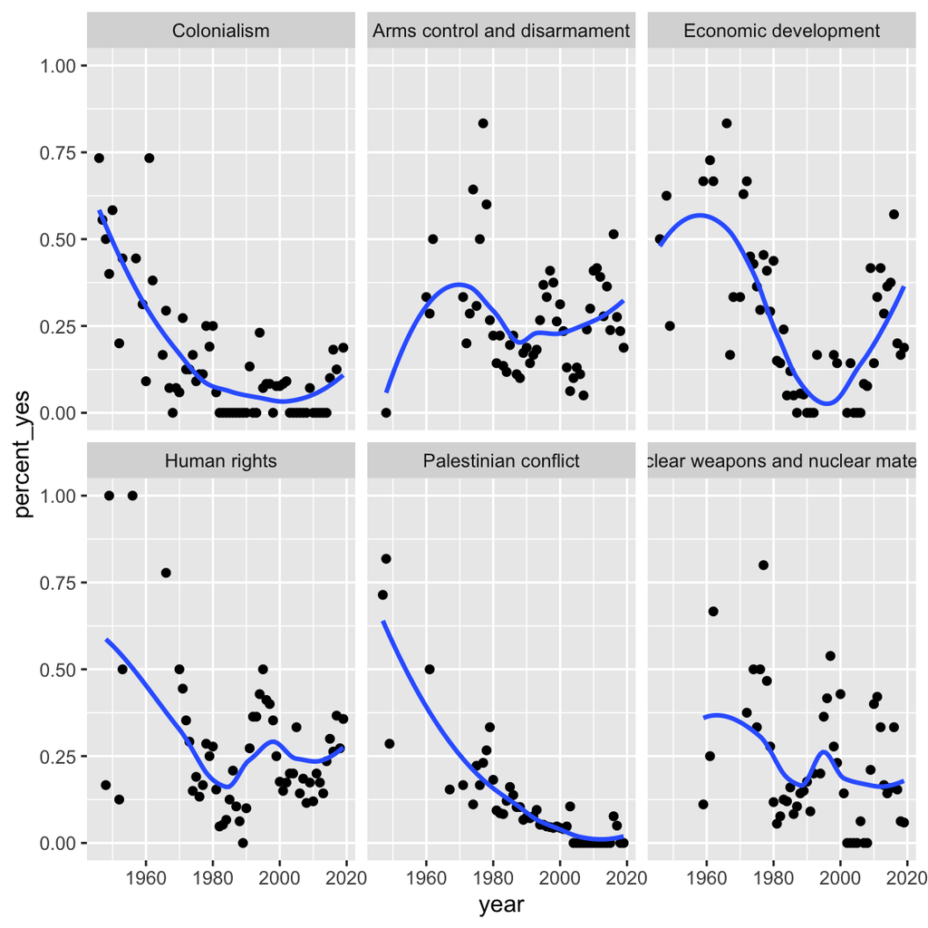

```r
joined %>%
  filter(country == "United States") %>%
  inner_join(un_roll_call_issues, by = "rcid") %>%
  group_by(year = year(date), issue) %>%
  summarize(votes = n(),
            percent_yes = mean(vote == "yes")) %>%
  filter(votes > 5) %>%
  ggplot(aes(year, percent_yes)) +
  geom_point() +
  geom_smooth(se = FALSE) +
  facet_wrap(~ issue)
```

### Code of Conduct

Please note that this project is released with a Contributor Code of Conduct. By participating in this project you agree to abide by its terms.